# Communicate-Data-Finding-Exploration-with-Ford-GoBike-System-Data

## by Harsha Priya Vallala

- Introduction of the topic and dataset
- Dataset Investigation and preliminary wrangling
- Further Data Wrangling
- Univariate Exploration and Analysis
- Bivariate Exploration and Analysis
- Multivariate Exploration and Analysis
- Conclusions and answers

## Preliminary Wrangling

- I chose Ford GoBike System Data : https://www.fordgobike.com/system-data as my source data
- This data set includes information about individual rides made in a bike-sharing system covering the greater San Francisco Bay area.
- The features included in the dataset : Trip Duration (seconds) , Start Time and Date , End Time and Date , Start Station ID , Start Station Name , Start Station Latitude , Start Station Longitude , End Station ID , End Station Name, End Station Latitude , End Station Longitude , Bike ID , User Type (Subscriber or Customer – “Subscriber” = Member or “Customer” = Casual) , Member Year of Birth, Member Gender

```python
# import all packages and set plots to be embedded inline
import numpy as np
import pandas as pd
import matplotlib.pyplot as plt
import seaborn as sb
import os
#import zipfile
%matplotlib inline
```

### Merging different csv files of all 12 months together in one main csv

```python
df = pd.read_csv('out.csv')
```

```python
df.shape
```

```
(1863721, 16)
```

```python
df_copy =  df.copy()
```

```python
df_copy.shape
```

```
(1863721, 16)
```

```python
df_copy.isnull().sum()
```

```
duration_sec                    0
start_time                      0
end_time                        0
start_station_id            11771
start_station_name          11771
start_station_latitude          0
start_station_longitude         0
end_station_id              11771
end_station_name            11771
end_station_latitude            0
end_station_longitude           0
bike_id                         0
user_type                       0
member_birth_year          110718
member_gender              110367
bike_share_for_all_trip         0
dtype: int64
```

```python
df.isnull().sum()
```

```
duration_sec                    0
start_time                      0
end_time                        0
start_station_id            11771
start_station_name          11771
start_station_latitude          0
start_station_longitude         0
end_station_id              11771
end_station_name            11771
end_station_latitude            0
end_station_longitude           0
bike_id                         0
user_type                       0
member_birth_year          110718
member_gender              110367
bike_share_for_all_trip         0
dtype: int64
```

### What is the structure of your dataset?

> The data set includes Multiple csv file with 1863721 rows and 16 columns

### What is/are the main feature(s) of interest in your dataset?

> The following questions are of my interest
> - How long does the average trip take?
> - Is the trip duration affected by weather( months/seasons)
> - Does the above depend on if a user is a subscriber or customer?

### What features in the dataset do you think will help support your investigation into your feature(s) of interest?

> Trip Duration (seconds), Start Time and Date , End Time and Date, User Type , Member Year of Birth , Member Gender

## Univariate Exploration

> In this section, investigate distributions of individual variables.

Question 1 : I want to know is " How long does the average trip take?"

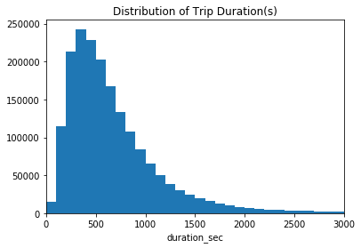

```python
# Let's plot the distribution of trip duration.
bin_edges = np.arange(0, df['duration_sec'].max() + 100 , 100)
plt.hist(data = df , x = 'duration_sec' , bins = bin_edges)
plt.xlim(0,3000)
plt.title('Distribution of Trip Duration(s)')
plt.xlabel('duration_sec')
```

> It is right screwed with a long tail on the right. I am going to add log transformation to x axis.

> It is really difficult to look at the plot. I had to increase the bin width to 100 to let the plot show. Measuring trip using seconds is not reasonable. I would change the "duration_sec" to "duration_min" before I add any log transformation .

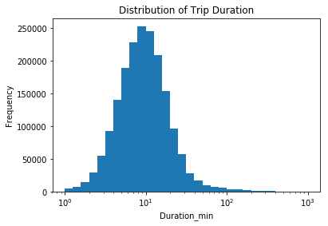

```python
# change the trip duration unit from second to min
df['duration_min'] = df['duration_sec'] / 60
df.drop('duration_sec' , axis = 1 , inplace = True)

bin_edges = 10**np.arange(0 , 3+0.1 , 0.1)
ticks =  [ 0.1 , 0.3 , 1 , 3, 10, 30, 100, 300]
labels = ['{}'.format(v) for v in ticks]
plt.hist(data = df , x = 'duration_min' , bins = bin_edges);
plt.xticks(ticks,labels);
plt.xlabel('Duration_min');
plt.xscale('log');
plt.title('Distribution of Trip Duration')
plt.ylabel('Frequency')
```

we can see through the plot, most people tend to use the bikes for short-time trips ( around 10 mins).

## Bivariate Exploration

> In this section, I would investigate relationships between pairs of variables in the data.

```python
# some data engineering should be conducted:
# create month_start column by extracting months of start_time

df['month_start'] = pd.DatetimeIndex(df['start_time']).month
df['month_start'].value_counts()


#method 2 to extract year, month, date
#df['start_time'] = pd.to_datetime(df['start_time'])

#df['start_year'] = df['start_time'].dt.year
#df['start_month'] = df['start_time'].dt.month
#df['start_day'] = df['start_time'].dt.day
```

```
10    201458
7     199222
6     195968
8     192162
9     186217
5     179125
11    134135
12    131363
4     131169
3     111382
2     106718
1      94802
Name: month_start, dtype: int64
```

### How did the feature(s) of interest vary with other features in the dataset?

Question 2. Does weather(month) affect the trip duration ?

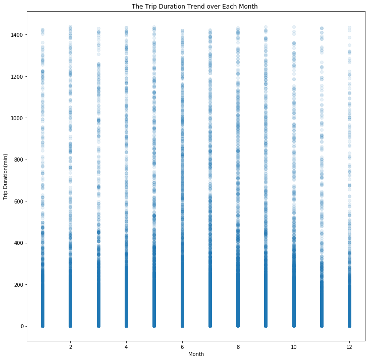

```python
# We can check the trip duration over changes over each month.
plt.figure(figsize = [12,12]) # make the whole figure bigger to show all
plt.scatter(data = df , x = 'month_start' , y = 'duration_min' , alpha = 0.1 )
plt.title('The Trip Duration Trend over Each Month ')
plt.xlabel('Month')
plt.ylabel('Trip Duration(min)')
```

June to Auguts in 2018 has the most duration. Other seasons do not have significant difference

Will weather(season) show a more obvious affect on trip duration ?

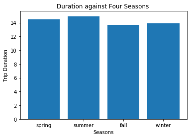

```python
# Create 4 season categories
spring_dur = df.query('month_start in ["3" , "4" , "5"]' ).duration_min.mean ()
summer_dur = df.query('month_start in ["6" , "7" , "8"] ').duration_min.mean()
fall_dur = df.query('month_start in ["9" , "10" , "11"] ').duration_min.mean()
winter_dur = df.query('month_start in ["12" , "1" , "2"]' ).duration_min.mean()
# here the month must be double quote characters, otherwise, give me systax errors


plt.bar(['spring','summer','fall','winter'],[spring_dur , summer_dur , fall_dur , winter_dur] )
plt.title('Duration against Four Seasons ')
plt.xlabel('Seasons')
plt.ylabel('Trip Duration');
```

```python
spring_dur , summer_dur , fall_dur , winter_dur
```

```
(14.478559960728035, 14.928832965580831, 13.66316596717842, 13.897462371664213)
```

- As we expected, summer has the longest trip duration , with average above 14 mins.
- But there is no significant difference of trip duration in terms of four seasons. It is probably because the weather in San Francisco bay area does not change that much.
- What surprised me the most is fall has the lowest trip duration in 2018. Fall is most likely to experience good weather with pleasant average temperatures in SF. People are more likely to go out and exercise .
- After checking the news, it is likely caused by Wildfires in Northern California(11/9/2018) which lead to the worst air quality in SF for months.

> The weather does affect trip duration, but the affect is very limited. Unlike cities like Boston, New York, which have very different four seasons, the weather in SF does not change that much.

## Multivariate Exploration

> Create plots of three or more variables to investigate the data even further.The investigations are justified, and follow from my work in the previous sections.

Question 4 : Does user type lead to the lower trip duration ?

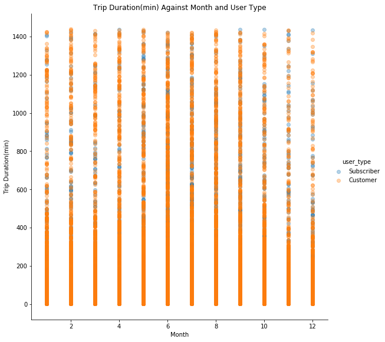

```python
# I want to find out if user type lead to the lower trip duration

g = sb.FacetGrid(data =  df, hue = 'user_type', size = 8)
g.map(plt.scatter, 'month_start','duration_min', alpha = 1/3)
g.add_legend()
plt.title('Trip Duration(min) Against Month and User Type')
plt.xlabel('Month')
plt.ylabel('Trip Duration(min)');
```